# **Analyse von Mikro- und Makrodaten und Erstellung eines Gemeinderatings**

## **Case Study BINA**

Eingereicht am 16. Juni 2023 von:

> Krähenbühl, Pascal, Customer Success Manager, Crowdhouse AG, Butzenstrasse 27 8038 Zürich, 044 377 90 71, pascal.kraehenbuehl@students.hslu.ch

> Grob, Jan-Evan, Core Category Manager, HP Schweiz GmbH, Neue Winterthurerstrasse 99 8304 Wallisellen, 079 128 85 93, jan.grob@ost.ch

> Toscan, Vanessa, Wissenschaftliche Assistentin, Institut für Modellbildung und Simulation - OST. Rosenbergstrasse 59 9001 St.Gallen, 079 304 23 99, vanessa.toscan@ost.ch

> Imhof, Thomas, Regulatory Project Manager bei Apiax, Leutholdstrasse 13, 8037 Zürich. 076 32 20 92, thomas.imhof01@stud.hslu.ch

## **Management Summary**

Diese Projektarbeit mit dem Titel "Analyse von Mikro- und Makrodaten und Erstellung eines Gemeinderatings" wurde im Rahmen des Moduls Business Intelligence & Analytics des Masterstudiengangs Wirtschaftsinformatik der Ostschweizer Fachhochschule, Hochschule Luzern und Berner Fachhochschule verfasst. Ziel der Arbeit war es, Datensätze exemplarisch durchzuarbeiten, um den Weg "von Daten zu Entscheidungen" plausibel aufzuzeigen, damit für das Unternehmen Crowdhouse Empfehlungen für einen potenziellen Use Case abgegegeben werden können. Die Arbeit beinhaltet eine Analyse von verschiedenen Mikro- und Makrolagendaten von Schweizer Gemeinden, die in Zusammenhang gebracht und ausgewertet wurden. Das Gemeinderating wurde auf Basis dieser Analyse erstellt. Die Arbeit schliesst mit einem Fazit und einer kritischen Würdigung der Ergebnisse.

## **1 Einleitung, Ausgangslage und Zielsetzung**

Crowdhouse ist eine Immobilientransaktionen- Plattform und spezialisiert sich auf das Immobilien Crowdfunding von Schweizer Renditeliegenschaften. Da das Unternehmen in einem „Blue- Ocean“ Markt agiert, ist es besonders wichtig, die Erwartungen der verschiedenen Stakeholder zu erfüllen, insbesondere der Kundennutzen sollte dabei im Zentrum stehen. Crowdhouse hat sich zum Ziel gesetzt, den intransparenten Immobilienmarkt mittels Plattform öffentlich zugänglich und transparent zu machen, sodass möglichst viele Personen daran teilnehmen können. Im Zentrum dabei steht das datenbasierte Matching von Käufer & Verkäuferschaft, wodurch möglichst faire und nachhaltige Preis Dynamiken entstehen sollen. Die Plattform wird dabei ständig weiterentwickelt und soll sich an den Bedürfnissen der Benutzer:innen ausrichten. Crowdhouse hat in der Vergangenheit immer wieder Tools aus Eigenentwicklung hervorgebracht, welche User in der Auswahl des richtigen Immobilieninvestments unterstützen sollen. So wurde ein Preis-Schätzer entwickelt, der aufgrund bestimmter Parameter eine ungefähre Verkaufspreisspanne der Immobilie angeben kann oder ein Tool, das auf Basis von Immobilien Grunddaten Ausnutzung Potenziale berechnet.

Beim Erwerb von Renditeimmobilien spielt der Standort, bestehend aus Mikro- und Makrolage, eine essenzielle Rolle, da er massgebend für die zukünftige Wertentwicklung sein wird.

Die Begriffe Mikro- und Makrolage werden häufig im Bereich der Immobilienbewertung und -beschreibung verwendet.

Die Mikrolage bezieht sich auf die unmittelbare Umgebung eines bestimmten Standorts. Hier werden Faktoren wie die Nähe zu Einkaufsmöglichkeiten, öffentlichen Verkehrsmitteln, Schulen und Arbeitsplätzen sowie die Qualität der Infrastruktur, der Nachbarschaft und der Landschaft berücksichtigt.

Die Makrolage hingegen bezieht sich auf die Lage eines Objekts im grösseren Kontext. Hier werden Faktoren wie die Region, die Stadt oder der Stadtteil, in dem sich das Objekt befindet, berücksichtigt. Auch politische, wirtschaftliche und gesellschaftliche Faktoren können hier eine Rolle spielen, beispielsweise die Arbeitsmarktsituation oder die Entwicklung des regionalen Immobilienmarktes.

Insgesamt ergibt sich die Lagebewertung eines Objekts aus der Betrachtung sowohl der Mikro- als auch der Makrolage.

### **1.1 Zielsetzung**

Das Makro- Mikrolagen- Datentool soll den Usern schnell und einfach die Möglichkeit bieten, attraktive Gemeinden für eine Investition in Renditeimmobilien identifizieren zu können. Es soll helfen, die bestmögliche Investitionsentscheidung zu treffen, indem es relevante Informationen über alle Schweizer Gemeinden und deren Aussichten für zukünftige Wertentwicklung aufzeigt und Risikofaktoren identifiziert, um passende Entscheidungsgrundlagen zu definieren.

Folgende Informationsgrundlagen müssen bei einer Investition in Renditeimmobilien in Betracht gezogen werden:

- Standort: Die Lage einer Immobilie ist ein wichtiger Faktor, der die Rendite beeinflussen kann. Primär geht es hier um Faktoren wie Infrastruktur, Anbindung an den öffentlichen Nahverkehr, Verfügbarkeit von Schulen und Einkaufsmöglichkeiten, welche Standorte wesentlich aufwerten können.
- Markt- Lage und Entwicklung: Auch die generelle Entwicklung der Marktgegebenheiten mit der allgemeinen Wirtschaftslage, Zinssätze und andere wirtschaftliche Trends können einen wesentlichen Einfluss auf die Rendite haben und müssen entsprechend berücksichtigt werden.
- Leerstandsziffer: Die Leerstandsziffer gibt an, wie viele Einheiten einer Immobilie im Leerstand sind. Eine hohe Leerstandsquote kann einen Standort wesentlich negativ beeinflussen.
- Alter und Zustand der Immobilie: Diese Faktoren können die Rendite einer Immobilie wesentlich beeinflussen, da ältere Immobilien oft höhere Instandhaltungskosten als neuere Immobilien verursachen und mit zeitnahen kapitalintensiven Renovationskosten zu rechnen sind.
- Mieteinnahmen: Die Höhe der Mieteinnahmen ist ein wichtiger Faktor, der die Rendite beeinflussen kann. Es muss festgestellt werden, ob sich diese im Marktniveau befinden oder ggf. noch optimiert werden können.
- Steuern und andere Kosten: In der föderalistischen Schweiz gibt es wesentliche Unterschiede bei der steuerlichen Handhabung.

### **1.2 Forschungsfragen**

Durch die Entwicklung von unterschiedlichen Daten soll mit Hilfe dieser Arbeit neues Wissen zum Thema Lagebewertung von Schweizer Gemeinden generiert werden. Ziel ist es, die Entwicklung selektierter Mikro- und Makrolagen- Daten aller Schweizer Gemeinden zu analysieren, um darauf basierend ein Ratingsystem zu entwickeln. Aufgrund der vorhandenen Daten und der Eingrenzung vom Thema wurden die folgenden Daten als essentiell für das Rating selektioniert:

### **1.3 Vorgehen**

Diese Projektarbeit wird im Rahmen des Master Studiums Wirtschaftsinformatik im Modul Business Intelligence und Analytics verfasst. Die Auswertung und Erläuterung wurden in der Gruppe mit Google Collaboratory erarbeitet. Die Arbeit wird nach der fünf Schritte der CPA Management Accounting Guideline „von Daten zu Entscheidungen“ (Marr, 2020) gegliedert.

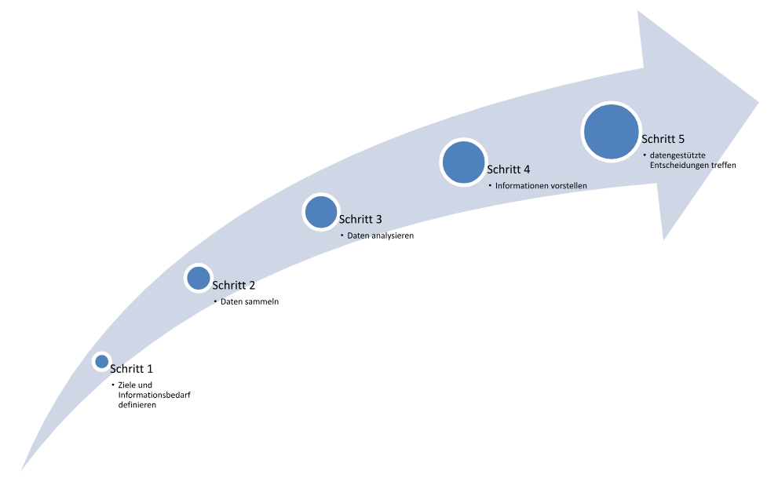

*1 - Ziele und Informationsbedarf definieren*

Im ersten Schritt wurden bereits im vorhergehenden Abschnitt die Zielsetzung sowie die benötigten Informationen zur Beantwortung der Forschungsfragen definiert. Die genaue Zieldefinition soll sicherstellen, dass im folgenden Schritt die richtigen Daten für die vorliegenden Fragestellungen gesammelt werden und die Projektziele somit eingehalten werden können.

*2 - Daten sammeln*

Danach werden im zweiten Schritt Rohdaten gesammelt. Der Fokus soll dabei auf genügend relevante und aussagekräftige Daten gelegt werden. Die Menge an Daten ist deshalb essentiell, weil je mehr Daten gesammelt werden können, desto genauere Aussagen können in Bezug auf die Allgemeinheit getroffen werden, um den in Schritt 1 identifizierten Informationsbedarf decken zu können.

*3 - Daten analysieren und visualisieren*

Sobald die richtigen Daten zusammengetragen wurden, geht es im dritten Schritt darum, die Daten zu analysieren und in Erkenntnisse umzuwandeln. Dabei gilt es, die passenden Analysetechniken auszuwählen, um möglichst präzise und nützliche Auswertungen zu visualisieren.

*4 - Daten präsentieren*

Im vierten Schritt werden die Ergebnisse aus dem vorherigen Schritt auf geeignete Weise präsentiert. Die Projektgruppe erstellt hierfür ein entsprechendes Template auf Google Collaboratory.

*5 - datengestützte Entscheidungen treffen*

Im fünften Schritt werden aufgrund der gewonnenen und präsentierten Ergebnisse, datengestützte Entscheidungen getroffen. Im Rahmen dieser Projektarbeit wird dieser Schritt aber nicht ausgearbeitet.

## **2 Daten sammeln**

Im nachfolgenden Kapitel wird der Schritt zwei der CPA Management Accounting Guideline «Collecting Data» ausgearbeitet. Ziel ist es, die richtigen Daten zu sammeln und zu organisieren. Ausschlaggebend sind aussagekräftige und relevante Daten, damit der identifizierte Informationsbedarf der Problemstellung und Ausgangslage gedeckt werden kann. Im Rahmen der Arbeit wurden verschiedene Quellen konsultiert. Das Verfahren zur Beschaffung der Daten variierte je nach Quelle, da bestimmte Daten auf öffentlichen Portalen frei zugänglich sind, während andere Daten bei Primärerhebern angefragt werden mussten. Nach der Guideline From Data to Desicion (Marr, 2020.) gibt es für die Sammlung der Daten zwei verschiedene Vorgehensweisen. Es kann auf bereits existierende Daten zurückgegriffen werden, oder die Daten müssen zuerst erhoben werden.

Durch die Arbeitstätigkeit von Pascal Krähenbühl beim Immobilienunternehmen Crowdhouse liegen dem Projektteam für die Case Study externe Daten vor, die mittels JSON Data File im Rahmen der Arbeit zur Verfügung gestellt wurden.

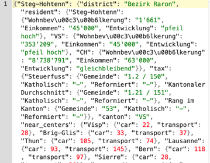

Das Unternehmen Crowdhouse kaufte die Daten einerseits über das Unternehmen Wüest&Partner, die nicht öffentlich zugänglich sind, ein. Andererseits wurden öffentlich zugängliche Datenquellen herbeigezogen. Das Ergebnis dieser Projektarbeit wird als Grundlage dienen, um den Unternehmen Crowdhouse die Grundlage für ein neues Digital Asset Tool zu bieten, welches im Verlaufe des Geschäftsjahres 2023 implementiert werden könnte. Als Vorbild hierfür soll das bereits existierende [Gemeinderating von der Raiffeisen Genossenschaft](https://www.raiffeisen.ch/rch/de/privatkunden/hypotheken/gemeindeinfo.html) dienen, was die Funktionalität und den Inhalt betrifft.

Das Data Science Team von Crowdhouse hat hierfür über das Bundesamt für Statistik (BFS) Datensätze zur Bevölkerung, Bau- und Steuerentwicklung herbeigezogen. Um die Datenmenge einzugrenzen, hat sich das Projektteam entschlossen, die Daten auf den Zeitraum von 2018-2021 zu beschränken. Für das Rating der jeweiligen Gemeinden wurde das aktuellste Makrolagen-Rating nach Wüest & Partner aller Schweizer Gemeinden von der Software "Wüest&Partner Dimensions” exportiert. Die Datenquellen wurden mittels JSON File der Gruppe zur Verfügung gestellt und in JSON bereinigt. Für die weitere Verarbeitung wurden die Datensätze mit Code von einem JSON File in mehrere Excel-Files umformatiert. Dabei hatte die Projektgruppe Unterstützung von einem Arbeitskollegen, der sich mit R-Programmierung auskennt.

Die nachfolgende Tabelle deklariert die Datenherkunft der zur Verfügung gestellten Daten:

| Name der Datenquelle | Beschreibung | Zugang | URL |
| --- | --- | --- | --- |
| Bundesamt für Raumentwicklung (ARE) | Das ARE ist die Fachbehörde für Raumplanung sowie für Fragen des Gesamtverkehrs und der nachhaltigen Entwicklung. | öffentlich | https://www.are.admin.ch/are/de/home/raumentwicklung-und-raumplanung/grundlagen-und-daten/publikationen.html |
| Bundesamt für Statistik (BFS) | Das Bundesamt für Statistik ist das nationale Kompetenzzentrum der öffentlichen Statistik der Schweiz. | öffentlich | https://www.bfs.admin.ch/bfs/de/home/statistiken/bevoelkerung.html |
| Eidgenössische Steuerverwaltung (ESTV) | Die Eidgenössische Steuerverwaltung ESTV ist zuständig für die MWST, die Verrechnungssteuer und die direkte Bundessteuer. | öffentlich | https://www.estv.admin.ch/estv/de/home.html |
| Wüest&Partner | Unternehmen, das Beratungsdienstleistungen und Forschungsanalysen in den Bereichen Immobilienbewertung, Immobilienmarktforschung, Portfolio- und Asset-Management, Strategieberatung sowie Standortentwi… | geschlossen (Zugang über Lizenz von Softwaretool Wüest Dimensions/ GeoInfo Crowdhouse) | https://www.wuestpartner.com/ch-de/ |

## **3 Daten analysieren und visualisieren**

Schritt 3 befasst sich mit der Analyse der gesammelten Daten. Dabei werden die Daten bereinigt, d.h. fehlerhafte, inkonsistente oder irrelevante Daten werden entfernt oder korrigiert. Danach werden statistische Methoden und zum Beispiel Data-Mining-Techniken eingesetzt, um Muster, Trends und Zusammenhänge in den Daten zu identifizieren. Ziel ist es, aus den Daten relevante Informationen zu gewinnen, die bei der Entscheidungsfindung helfen. Eine wichtige Aufgabe in diesem Schritt ist es, die Daten so zu visualisieren, dass sie leicht verständlich sind und die gewonnenen Erkenntnisse klar und anschaulich präsentiert werden können. Für die Bereinigung der Daten wurde wie folgt vorgegangen (ChatGPT, 2023)

1. Überprüfung der Datenqualität: Vor der Bereinigung wird sichergestellt, dass die Datenqualität akzeptabel ist. Dazu gehört das Überprüfen auf fehlende Werte, inkonsistente Daten oder fehlerhafte Einträge. Auch sollten mögliche Duplikate oder Ungereimtheiten geprüft werden.
2. Entfernen von Duplikaten: Duplikate können die Ergebnisse verfälschen und sollten daher entfernt werden.
3. Entfernen von irrelevanten Spalten: Wenn Spalten nicht relevant für die Analyse sind oder nur sehr wenige Informationen enthalten, sollten sie entfernt werden, um die Datenmenge zu reduzieren und die Analyse zu erleichtern.
4. Korrigieren von Fehlern: Wenn fehlerhafte Einträge in der Datenbank vorhanden sind, sollten diese korrigiert werden. Dies kann manuell oder durch automatische Korrektur erfolgen.
5. Anpassen von Datentypen: Datentypen sollten angepasst werden, um sicherzustellen, dass sie mit den Daten kompatibel sind. Beispielsweise kann es sinnvoll sein, die Spalte "Datum" in ein Datumsformat zu konvertieren.
6. Überprüfen der Einheitlichkeit: Wenn die Daten in unterschiedlichen Einheiten vorliegen, sollten diese in eine Einheit umgewandelt werden, um die Vergleichbarkeit zu erleichtern.
7. Bereinigen von fehlenden Werten: Fehlende Werte sollten entweder ergänzt oder entfernt werden. Dies hängt von der Anzahl und Bedeutung der fehlenden Werte ab. In einigen Fällen ist es sinnvoll, diese ergänzen zu lassen, in anderen Fällen ist es sinnvoll, die betroffenen Datensätze zu entfernen.

### **Überprüfung der Datenqualität**

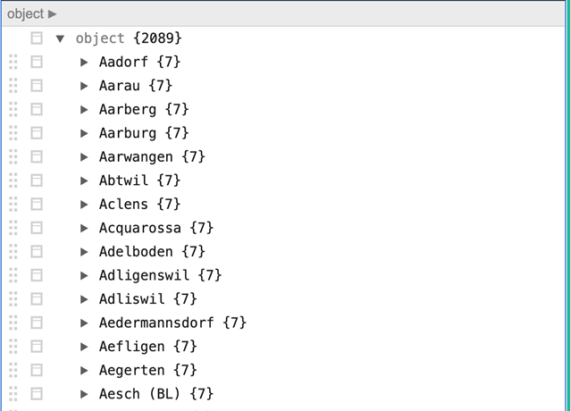

### **Erstellung der Daten Entität:**

**Bevölkerung:**

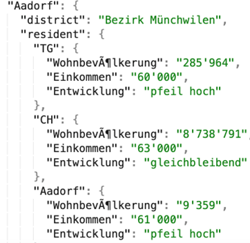

Die Entität Gemeindename hat das Attribut District und eine Beziehung zur Entität “resident”. Die Entität “resident” wiederum hat eine Beziehung zu den Attributen “TG”, “CH” und “Gemeindename”. Diese wiederum verfügen je über die Attribute “Wohnbevölkerung”, “Einkommen” und “Entwicklung”.

Dieses Schema wiederholt sich mit den restlichen Datensätzen. Um dieses vollständig zu verstehen, werden die Entitäten anhand des Datensatzes “Aadorf” wie folgt veranschaulicht:

"Aadorf": Objekt mit Informationen über die Stadt Aadorf

"Bezirk": String, der den Bezirk angibt, zu dem Aadorf gehört

"Einwohner": Objekt, das Informationen über die Einwohner von Aadorf enthält:

"TG": Objekt, das Informationen über die Einwohner von Aadorf enthält, die im Kanton Thurgau wohnen

"Einkommen": String, der das mittlere Einkommen der im Kanton Thurgau wohnhaften Aadorferinnen und Aadorfer darstellt

"Entwicklung": String, der den Trend der Einkommensentwicklung der Aadorfer Bevölkerung im Kanton Thurgau darstellt

"CH": Objekt mit Informationen über die in der Schweiz wohnhaften Aadorferinnen und Aadorfer (ohne Thurgauerinnen und Thurgauer)

"Einkommen": String, der das Medianeinkommen der in der Schweiz lebenden Aadorferinnen und Aadorfer darstellt

"Entwicklung": String, der den Trend der Einkommensentwicklung der in der Schweiz lebenden Aadorferinnen und Aadorfer darstellt

"Aadorf": Objekt mit Informationen über die Einwohner von Aadorf, die innerhalb der Gemeindegrenzen wohnen

"Wohnbevölkerung": String, der die Gesamtbevölkerung von Aadorf darstellt, die innerhalb der Gemeindegrenzen wohnt

"Einkommen": String, der das mittlere Einkommen der Aadorferinnen und Aadorfer innerhalb der Gemeindegrenzen darstellt

"Entwicklung": String, der den Trend der Einkommensentwicklung der Aadorferinnen und Aadorfer innerhalb der Gemeindegrenzen darstellt

"Steuer": Objekt, das steuerliche Informationen für Aadorf enthält, darunter:

"Steuerfuss": Objekt, das den Steuersatz in Aadorf für verschiedene Kategorien darstellt, darunter:

"Gemeinde": Zahl, die den Steuersatz für die Gemeinde Aadorf angibt

"Katholisch": Zahl, die den Steuersatz für die Katholiken in Aadorf angibt

"Reformiert": Zahl, die den Steuerfuss für die Protestanten in Aadorf angibt

"Kantonaler Durchschnitt": Objekt, das den durchschnittlichen Steuerfuss im Kanton Thurgau für verschiedene Kategorien darstellt

"Rang im Kanton": Objekt, das die Rangfolge der Steuersätze von Aadorf innerhalb des Kantons Thurgau für verschiedene Kategorien darstellt

"Kanton": String, der den Kanton angibt, zu dem Aadorf gehört

"nahe_Zentren": Objekt, das die Nähe von Aadorf zu anderen Städten darstellt, darunter:

"Winterthur": Objekt, das die Nähe von Aadorf zur Stadt Winterthur darstellt, einschließlich der Reisezeit mit dem Auto und den öffentlichen Verkehrsmitteln

"St. Gallen": Objekt, das die Nähe von Aadorf zur Stadt St. Gallen darstellt, inklusive Fahrzeit mit dem Auto und mit öffentlichen Verkehrsmitteln

"Frauenfeld": Objekt, das die Nähe von Aadorf zur Stadt Frauenfeld darstellt, inklusive Fahrzeit mit dem Auto und mit öffentlichen Verkehrsmitteln

"Wil (SG)": Objekt, das die Nähe von Aadorf zur Stadt Wil (SG) darstellt, inklusive Fahrzeit mit dem Auto und mit öffentlichen Verkehrsmitteln

"Uzwil": Objekt, das die Nähe von Aadorf zur Stadt Uzwil darstellt, inklusive Fahrzeit mit dem Auto und mit öffentlichen Verkehrsmitteln

"Kreuzlingen": Objekt, das die Nähe von Aadorf zur Stadt Kreuzlingen darstellt, inklusive Fahrzeit mit dem Auto und mit öffentlichen Verkehrsmitteln

### **Herleitung und Definition der einzelnen Daten-Parameter**

Der json-Datensatz enthält Informationen zur Bevölkerung und Einkommen und deren Entwicklung, dem Steuerfuss nach Gemeinde und Religion sowie Nähe und Distanz zu umliegenden Gemeinden, ausgehend von der jeweiligen Gemeinde. Um die Lage der Gemeinde ausgehend von den vorhandenen Daten zu werten, wird wie folgt vorgegangen:

### **Bevölkerung und Einkommen:**

**Bevölkerung**

*Vorgehensweise:* Der untenstehende Code erstellt Barplots für die Wohnbevölkerungsentwicklung in den verschiedenen Gemeinden.

Zuerst wird auf eine extrahierte Excel-Datei zugegriffen und die Daten in ein Pandas DataFrame geladen. Dann wird eine Liste der eindeutigen Werte in der Spalte "city" erstellt, um die verschiedenen Gemeinden zu identifizieren.

Anschliessend wird eine Schleife durch die ersten fünf Gemeinden in der Liste durchgeführt (damit es übersichtlicher wird, wurden nur die ersten fünf Plots im Colab angezeigt). Für jede Gemeinde werden die entsprechenden Daten aus dem DataFrame gefiltert. Es wird angenommen, dass das DataFrame eine Spalte "city" für den Gemeindenamen, eine Spalte "Wohnbevölkerung" für die Anzahl der Einwohner und eine Spalte "Entwicklung" für die Entwicklung der Wohnbevölkerung der jeweiligen Gemeinde enthält.

Die Werte in der Spalte "Wohnbevölkerung" werden in Integer umgewandelt und ein Farbcode sowie eine Beschriftung für jede Bar im Barplot werden basierend auf den Werten in der Spalte "Entwicklung" festgelegt. Der Barplot zeigt die Wohnbevölkerung auf der y-Achse und die Entwicklung der Wohnbevölkerung auf der x-Achse an.

Es wird auch eine Legende erstellt, die die Farbcodes und Beschriftungen für die Entwicklung der Wohnbevölkerung enthält. Die Achsenbeschriftungen und der Titel des Plots werden entsprechend der aktuellen Gemeinde angepasst. Bei der Bevölkerungsentwicklung gab es im json File die Indikationen “pfeil hoch”, “gleichbleibend” und “pfeil tief”. Um dies im Barplot entsprechend widerspiegeln zu können, wurde der Barplot bei positiver Entwicklung mit grüner Farbe, bei gleichbleibender Entwicklung mit orangener Farbe und bei negativer Entwicklung mit roter Farbe eingefärbt.

Die y-Achse wird so skaliert, dass sie Platz für die höchste Wohnbevölkerungszahl plus 1000 bietet, und die x-Achsenticks werden entfernt.

Der Code zeigt schliesslich den Barplot für jede der ersten fünf Städte in separaten Diagrammen an.

```python
# Libraries laden
import pandas as pd
import numpy as np
import matplotlib.pyplot as plt
import warnings
import plotly.express as px
import plotly.graph_objects as go
import openpyxl
```

```python
# Mounting Google Drive
from google.colab import drive
drive.mount ("/content/gdrive", force_remount=True)
```

### **Code Auswertung Bevölkerung**

```python
# Auf Excel-Datei zugreifen
file_path = '/content/gdrive/MyDrive/datasets/table_residents.xlsx'
data = pd.read_excel(file_path)
```

```python
# Überprüfen der Datenstruktur
data.info()
```

```
<class 'pandas.core.frame.DataFrame'>
RangeIndex: 2089 entries, 0 to 2088
Data columns (total 5 columns):
 #   Column           Non-Null Count  Dtype
---  ------           --------------  -----
 0   Unnamed: 0       2089 non-null   int64
 1   city             2089 non-null   object
 2   Wohnbevölkerung  2089 non-null   object
 3   Einkommen        2089 non-null   object
 4   Entwicklung      2089 non-null   object
dtypes: int64(1), object(4)
memory usage: 81.7+ KB
```

```python
# Erste Einträge anzeigen
data.head()
```

|  | Unnamed: 0 | city | Wohnbevölkerung | Einkommen | Entwicklung |
| --- | --- | --- | --- | --- | --- |
| 0 | 1 | Aadorf | 9'359 | 61'000 | pfeil hoch |
| 1 | 2 | Aarau | 21'773 | 64'000 | gleichbleibend |
| 2 | 3 | Aarberg | 4'600 | 55'000 | gleichbleibend |
| 3 | 4 | Aarburg | 8'562 | 52'000 | pfeil hoch |
| 4 | 5 | Aarwangen | 4'715 | 51'000 | pfeil hoch |

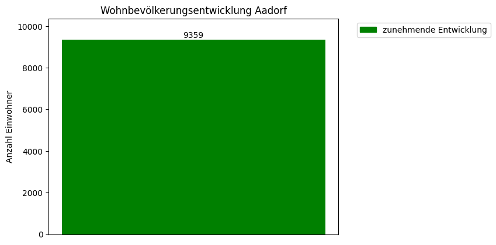

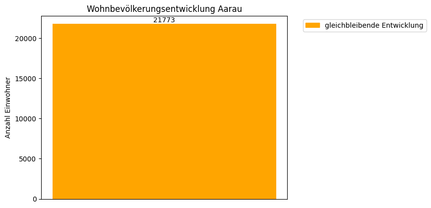

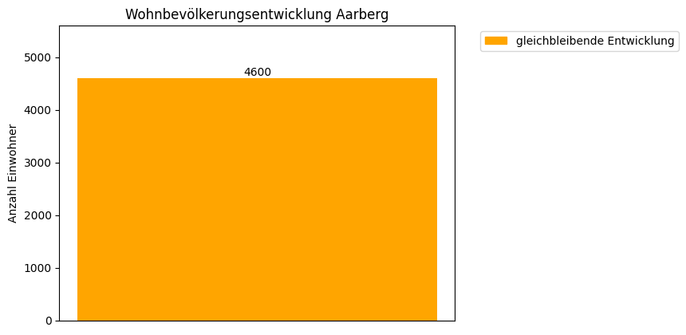

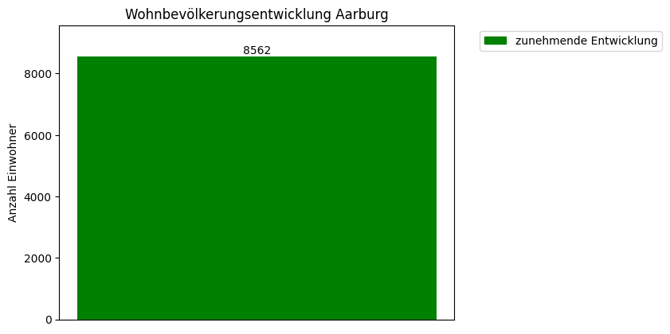

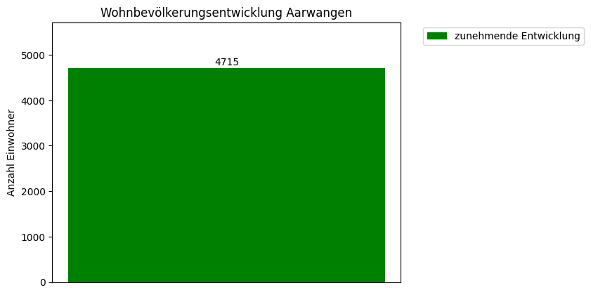

```python
# Erstellen einer Liste der eindeutigen Werte in der Spalte "city"
cities = data['city'].unique()

# Erstellen eines Barplots für jede Stadt
for city in cities[:5]:  # Begrenzung der Schleife auf die ersten fünf Gemeinden
    # Filtern der Daten für die aktuelle Stadt
    city_data = data[data['city'] == city].copy()

    # Restlicher Code für den Barplot
    city_data['Wohnbevölkerung'] = city_data['Wohnbevölkerung'].str.replace("'", "").astype(int)

    colors = []
    labels = []
    for development in city_data['Entwicklung']:
        if development == 'pfeil hoch':
            colors.append('green')
            labels.append('zunehmende Entwicklung')
        elif development == 'gleichbleibend':
            colors.append('orange')
            labels.append('gleichbleibende Entwicklung')
        elif development == 'pfeil tief':
            colors.append('red')
            labels.append('abnehmende Entwicklung')

    plt.bar(range(len(city_data)), city_data['Wohnbevölkerung'], color=colors)

    for i, val in enumerate(city_data['Wohnbevölkerung']):
        plt.text(i, val + 10, str(val), ha='center', va='bottom')

    plt.ylabel('Anzahl Einwohner')
    plt.title(f'Wohnbevölkerungsentwicklung {city}')

    legend_labels = list(set(labels))
    legend_colors = [colors[labels.index(label)] for label in legend_labels]
    legend_handles = [plt.Rectangle((0, 0), 1, 1, color=color) for color in legend_colors]
    plt.legend(legend_handles, legend_labels, bbox_to_anchor=(1.05, 1), loc='upper left')

    plt.ylim(0, city_data['Wohnbevölkerung'].max() + 1000, 500)

    plt.xticks([])

    plt.show()
```

Beim Bevölkerungswachstum wird in den Daten der Zeitraum 2018-2021 betrachtet. Es positiv zu bewerten, wenn eine Gemeinde eine zunehmende Wohnbevölkerungsentwicklung aufweist. Gemeinden mit einer zunehmenden Wohnbevölkderungsentwicklung werden als attraktiv angesehen.

**Einkommen**

*Vorgehensweise:*

### **Code Auswertung Einkommen**

```python
# Auf Excel-Datei zugreifen
file_path = '/content/gdrive/MyDrive/datasets/table_residents.xlsx'
data = pd.read_excel(file_path)
```

```python
# Überprüfen der Datenstruktur
data.info()
```

```
<class 'pandas.core.frame.DataFrame'>
RangeIndex: 2089 entries, 0 to 2088
Data columns (total 5 columns):
 #   Column           Non-Null Count  Dtype
---  ------           --------------  -----
 0   Unnamed: 0       2089 non-null   int64
 1   city             2089 non-null   object
 2   Wohnbevölkerung  2089 non-null   object
 3   Einkommen        2089 non-null   object
 4   Entwicklung      2089 non-null   object
dtypes: int64(1), object(4)
memory usage: 81.7+ KB
```

```python
# Erste Einträge anzeigen
data.head()
```

|  | Unnamed: 0 | city | Wohnbevölkerung | Einkommen | Entwicklung |
| --- | --- | --- | --- | --- | --- |
| 0 | 1 | Aadorf | 9'359 | 61'000 | pfeil hoch |
| 1 | 2 | Aarau | 21'773 | 64'000 | gleichbleibend |
| 2 | 3 | Aarberg | 4'600 | 55'000 | gleichbleibend |
| 3 | 4 | Aarburg | 8'562 | 52'000 | pfeil hoch |
| 4 | 5 | Aarwangen | 4'715 | 51'000 | pfeil hoch |

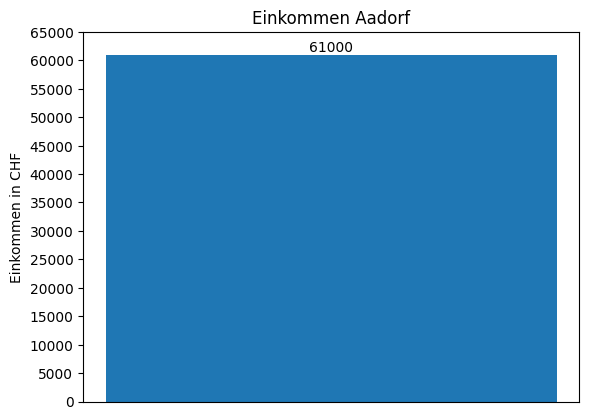

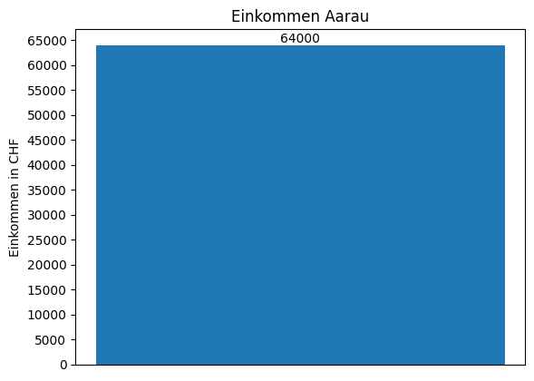

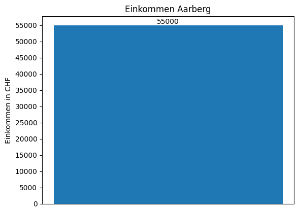

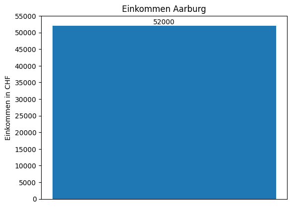

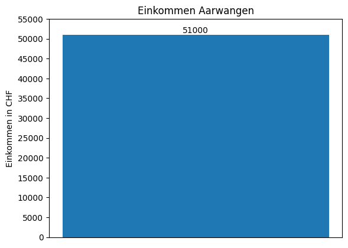

```python
# Erstellen einer Liste der eindeutigen Werte in der Spalte "city"
cities = data['city'].unique()

# Zählvariable für die Anzahl der Diagramme
diagram_count = 0

# Erstellen eines Barplots für jede Stadt
for city in cities:
    # Abbruchbedingung nach 5 Diagrammen
    if diagram_count >= 5:
        break

    # Filtern der Daten für die aktuelle Stadt
    city_data = data[data['city'] == city].copy()

    # Konvertierung der Werte in der Spalte "Wohnbevölkerung" in numerische Werte
    city_data['Einkommen'] = city_data['Einkommen'].str.replace("'", "").astype(int)

    # Erstellen des Barplots mit Matplotlib
    plt.bar(range(len(city_data)), city_data['Einkommen'])

    # Werte oberhalb des Balkens hinzufügen
    for i, val in enumerate(city_data['Einkommen']):
        plt.text(i, val + 10, str(val), ha='center', va='bottom')

    # Anpassung der Achsenbeschriftungen und des Titels
    plt.ylabel('Einkommen in CHF')
    plt.title(f'Einkommen {city}')

    # Anpassung der Y-Achse
    y_ticks = np.arange(0, city_data['Einkommen'].max() + 5000, 5000)
    plt.yticks(y_ticks)

    # Entfernung der Zahlen auf der X-Achse
    plt.xticks([])

    # Grafik anzeigen
    plt.show()

    # Zähler erhöhen
    diagram_count += 1
```

Ausgehend ist jeweils der Stand des durchschnittlichen steuerbaren Einkommens in CHF Stand 2019. Grundsätzlich ist es positiv zu bewerten, wenn eine Gemeinde im durchschnittlichen Einkommen einen möglichst hohen Wert vorweisen kann.

**Steuerfuss**

*Vorgehensweise:*

Der untenstehende Code erstellt Barplots für Steuerwerte und den kantonalen Steuer-Durchschnitt für die verschiedenen Gemeinden.

Zunächst wird auf die extrahierte Excel-Datei zugegriffen und die Daten in ein Pandas DataFrame geladen. Die auftretende Warnung, die während des Lesens der Excel-Datei auftreten kann, wird übersteuert.

Die Daten werden nach dem Wert "Gemeinde" in der Spalte "type" gefiltert, um nur die relevanten Daten für Gemeinden zu erhalten. Anschliessend werden die gefilterten Daten nach "city" gruppiert.

Die Variable "plot_count" wird als Zähler für die Anzahl der erstellten Barplots initialisiert.

Es wird über die Gruppen in "grouped_data" iteriert und für jede Gruppe wird ein Barplot erstellt. Die Schleife wird beendet, wenn fünf Barplots erstellt wurden.

Für jeden Barplot werden die Werte für den Steuerfuss und den kantonalen Durchschnitt aus der entsprechenden Gruppe extrahiert. Diese Werte werden in numerische Werte konvertiert.

Die x-Koordinaten für die Balken werden mit "np.arange" erzeugt, und es werden Balken für den Steuerfuss und den kantonalen Durchschnitt erstellt.

Die Achsenbeschriftungen und der Titel des Plots werden entsprechend der aktuellen Gemeinde angepasst. Eine Legende wird erstellt, um die Balken für den Steuerfuss und den kantonalen Durchschnitt zu kennzeichnen.

Die x-Achsenticks werden angepasst, um keine Beschriftungen zu haben. Die y-Achse wird so skaliert, dass sie Platz für den höchsten Wert der Steuerfuss- und Durchschnittsdaten plus 10 bietet.

Die Werte für den Steuerfuss und den kantonalen Durchschnitt werden über den Balken angezeigt. Die Grafik wird angezeigt und die Schleife wird für jede Gemeinde wiederholt, bis fünf Barplots erstellt wurden.

Es ist zu beachten, dass dieser Code voraussetzt, dass das DataFrame die Spalten "type", "city", "Steuerfuss" und "Kantonaler Durchschnitt" enthält.

### **Code Auswertung Steuerfuss**

```python
# Auf Excel-Datei zugreifen
file_path = '/content/gdrive/MyDrive/datasets/table_tax.xlsx'
data = pd.read_excel(file_path)
# Warnung ignorieren
warnings.filterwarnings("ignore", category=UserWarning, module="openpyxl")
```

```python
# Überprüfen der Datenstruktur
data.info()
```

```
<class 'pandas.core.frame.DataFrame'>
RangeIndex: 6267 entries, 0 to 6266
Data columns (total 6 columns):
 #   Column                   Non-Null Count  Dtype
---  ------                   --------------  -----
 0   Unnamed: 0               6267 non-null   int64
 1   city                     6267 non-null   object
 2   type                     6267 non-null   object
 3   Kantonaler Durchschnitt  6267 non-null   object
 4   Rang im Kanton           6267 non-null   object
 5   Steuerfuss               6267 non-null   object
dtypes: int64(1), object(5)
memory usage: 293.9+ KB
```

```python
# Erste Einträge anzeigen
data.head()
```

|  | Unnamed: 0 | city | type | Kantonaler Durchschnitt | Rang im Kanton | Steuerfuss |
| --- | --- | --- | --- | --- | --- | --- |
| 0 | 1 | Aadorf | Gemeinde | 142.7 | 41 | 145 |
| 1 | 2 | Aadorf | Katholisch | 20.9 | 29 | 19 |
| 2 | 3 | Aadorf | Reformiert | 23.7 | 12 | 19 |
| 3 | 4 | Aarau | Gemeinde | 105.6 | 40 | 97 |
| 4 | 5 | Aarau | Katholisch | 19.4 | 29 | 18 |

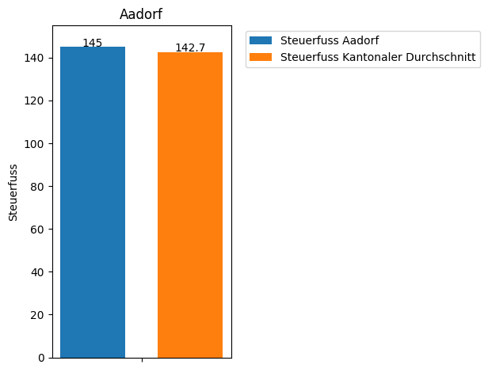

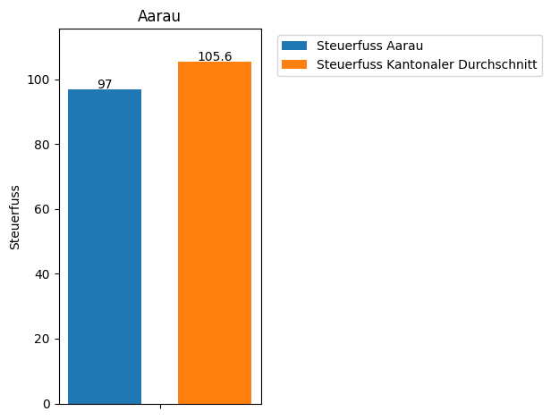

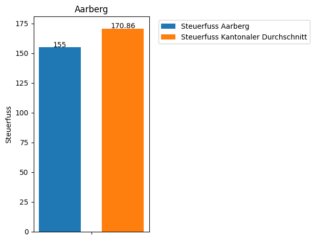

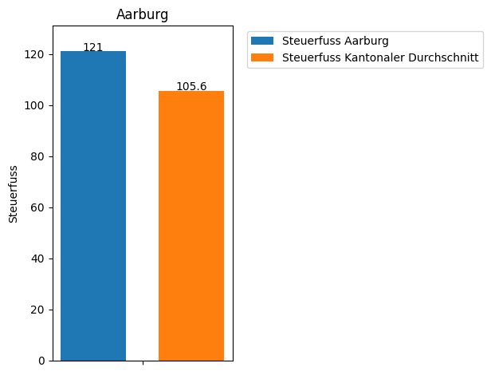

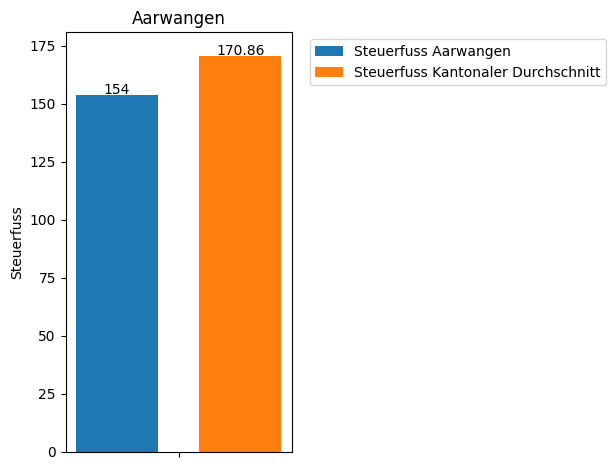

```python
# Filtern der Daten nach dem Wert "Gemeinde" in der Spalte "type"
filtered_data = data[data['type'] == 'Gemeinde']

# Gruppieren der gefilterten Daten nach "city"
grouped_data = filtered_data.groupby('city')

# Zählervariable für die Anzahl der erstellten Barplots
plot_count = 0

# Iterieren über die Gruppen und erstelle eines Barplots für jede Gruppe
for city, group in grouped_data:
    if plot_count >= 5:
        break  # Schleife beenden, wenn fünf Barplots erstellt wurden

    # Zähler um eins erhöhen
    plot_count += 1

    # Restlicher Code für den Barplot
    steuerfuss_values = pd.to_numeric(group['Steuerfuss'], errors='coerce')
    durchschnitt_values = pd.to_numeric(group['Kantonaler Durchschnitt'], errors='coerce')

    x = np.arange(len(steuerfuss_values))
    bar_width = 0.4
    bar_gap = 0.2

    plt.bar(x, steuerfuss_values, width=bar_width, label='Steuerfuss')
    plt.bar(x + bar_width + bar_gap, durchschnitt_values, width=bar_width, label='Kantonaler Durchschnitt')

    plt.ylabel('Steuerfuss')
    plt.title(city)

    legend_text = f'Steuerfuss {city}'
    plt.legend([legend_text, 'Steuerfuss Kantonaler Durchschnitt'], bbox_to_anchor=(1.05, 1), loc='upper left')

    x_ticks = x + bar_width / 2 + bar_gap / 2
    x_tick_labels = [''] * len(x)
    plt.xticks(x_ticks, x_tick_labels)

    max_value = max(max(steuerfuss_values.dropna()), max(durchschnitt_values.dropna()))
    plt.ylim(0, max_value + 10)

    for i, v in enumerate(steuerfuss_values):
        plt.text(i, v + 0.2, str(v), ha='center')

    for i, v in enumerate(durchschnitt_values):
        plt.text(i + bar_width + bar_gap, v + 0.2, str(v), ha='center')

    plt.tight_layout()
    plt.show()
```

Hier wird der Steuerfuss der Gemeinde in absoluten Zahlen mit den restlichen Gemeinden im Kanton verglichen. Hier ist es positiv für eine Gemeinde zu werten, je tiefer der absolute Steuerfuss ist und ob er geringer ist als der durchschnittliche kantonale Steuerfuss.

**Nähe zu umliegenden Zentren und Gemeinden (Mikrolagenrating)**

*Vorgehensweise:*

Der untenstehende Code erstellt Balkendiagramme, um die Distanzen zu anderen Gemeinden für die Verkehrsmittel öV und Auto zu vergleichen.

Zunächst wird auf die extrahierte Excel-Datei zugegriffen und die Daten in ein Pandas DataFrame geladen.

Es wird eine Liste der eindeutigen Werte in der Spalte "city" erstellt, um die verschiedenen Gemeinden zu identifizieren und die Breite der Balken wird festgelegt.

Dann wird eine Schleife durch die ersten fünf eindeutigen Gemeinden in der Liste durchgeführt. Für jede Gemeinde werden die entsprechenden Daten aus dem DataFrame gefiltert.

Es wird eine Liste der eindeutigen Werte in der Spalte "near_center" für die aktuelle Gemeinde erstellt und die Positionen für die x-Achse festgelegt.

Danach wird ein Balkendiagramm erstellt, wobei für jeden eindeutigen Wert in der Spalte "near_center" Balken für "by=car" und "by=transport" erstellt werden. Die Balken für "by=car" werden in grauer Farbe dargestellt, während die Balken für "by=transport" grün sind.

Die Werte für "by=car" und "by=transport" werden oberhalb der Balken hinzugefügt.

Die Achsenbeschriftungen und der Titel des Plots werden entsprechend der aktuellen Gemeinde angepasst. Die x-Achsenticks werden mit den eindeutigen Werten aus der Spalte "near_center" beschriftet und die y-Achse wird entsprechend der maximalen Distanz in den Daten angepasst.

Eine Legende wird mit den entsprechenden Farben und Bezeichnungen für "Distanz mit dem Auto" und "Distanz mit dem ÖV" erstellt und angezeigt. Schliesslich wird das Balkendiagramm für jede der ersten fünf Gemeinden in separaten Diagrammen angezeigt.

Es ist zu beachten, dass dieser Code voraussetzt, dass das DataFrame die Spalten "city", "near_center", "by", und "distance" enthält.

### **Code Auswertung Distanzen**

```python
# Auf Excel-Datei zugreifen
file_path = '/content/gdrive/MyDrive/datasets/table_near_centers.xlsx'
data = pd.read_excel(file_path)
# Warnung ignorieren
warnings.filterwarnings("ignore", category=UserWarning, module="openpyxl")
```

```python
# Überprüfen der Datenstruktur
data.info()
```

```
<class 'pandas.core.frame.DataFrame'>
RangeIndex: 25068 entries, 0 to 25067
Data columns (total 5 columns):
 #   Column       Non-Null Count  Dtype
---  ------       --------------  -----
 0   Unnamed: 0   25068 non-null  int64
 1   city         25068 non-null  object
 2   near_center  25068 non-null  object
 3   by           25068 non-null  object
 4   distance     25068 non-null  int64
dtypes: int64(2), object(3)
memory usage: 979.3+ KB
```

```python
# Erste Einträge anzeigen
data.head()
```

|  | Unnamed: 0 | city | near_center | by | distance |
| --- | --- | --- | --- | --- | --- |
| 0 | 1 | Aadorf | Frauenfeld | car | 19 |
| 1 | 2 | Aadorf | Frauenfeld | transport | 34 |
| 2 | 3 | Aadorf | Kreuzlingen | car | 38 |
| 3 | 4 | Aadorf | Kreuzlingen | transport | 92 |
| 4 | 5 | Aadorf | St-Gallen | car | 37 |

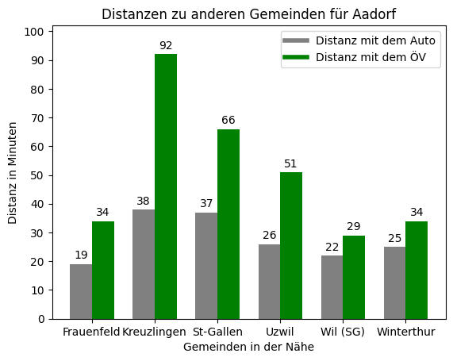

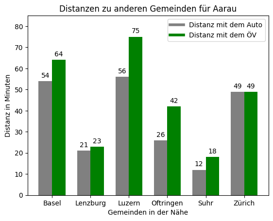

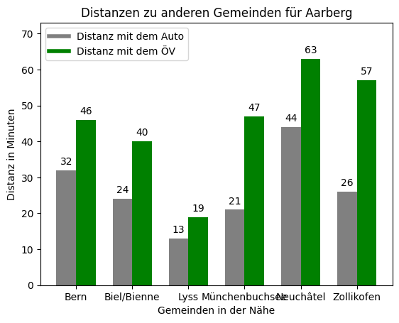

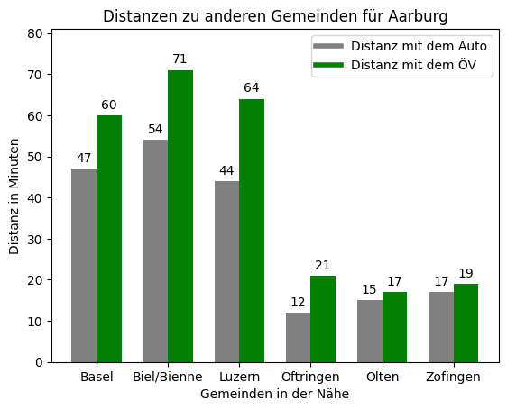

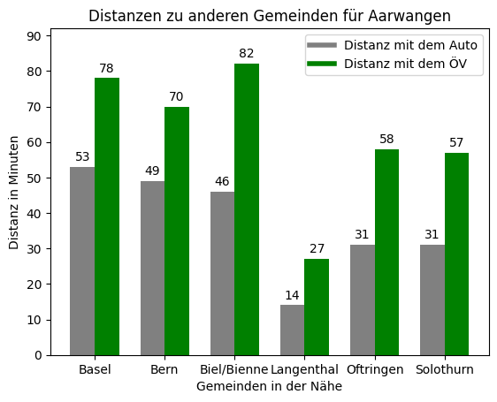

```python
# Eindeutige Werte in der Spalte "city"
unique_cities = data['city'].unique()

# Breite der Balken
bar_width = 0.35

# Für jeden eindeutigen Wert ein separates Balkendiagramm erstellen
for city in unique_cities[:5]:  # Begrenzung der Schleife auf die ersten fünf Gemeinden
    # Filtern der Daten für den aktuellen Wert in der Spalte "city"
    city_data = data[data['city'] == city]

    # Eindeutige Werte in der Spalte "near_center"
    unique_near_center = city_data['near_center'].unique()

    # Positionen für die X-Achse
    x = np.arange(len(unique_near_center))

    # Balkendiagramm erstellen
    for i, near_center_val in enumerate(unique_near_center):
        # Filtern der Daten für den aktuellen Wert in der Spalte "near_center"
        near_center_data = city_data[city_data['near_center'] == near_center_val]

        # Werte für "by=car"
        by_car_values = near_center_data[near_center_data['by'] == 'car']['distance']

        # Werte für "by=transport"
        by_transport_values = near_center_data[near_center_data['by'] == 'transport']['distance']

        # Balken für "by=car" erstellen
        plt.bar(x[i] - bar_width / 2, by_car_values, width=bar_width, label='by=car', color='gray')

        # Balken für "by=transport" erstellen
        plt.bar(x[i] + bar_width / 2, by_transport_values, width=bar_width, label='by=transport', color='green')

        # Wert oberhalb des Balkens hinzufügen
        for j, val in enumerate(by_car_values):
            plt.text(x[i] - bar_width / 2, val + 1, str(val), ha='center', va='bottom', color='black')

        for j, val in enumerate(by_transport_values):
            plt.text(x[i] + bar_width / 2, val + 1, str(val), ha='center', va='bottom', color='black')

    # Achsenbeschriftungen und Titel hinzufügen
    plt.xlabel('Gemeinden in der Nähe')
    plt.ylabel('Distanz in Minuten')
    plt.title(f'Distanzen zu anderen Gemeinden für {city}')

    # X-Achse beschriften
    plt.xticks(x, unique_near_center)

    # Y-Achse anpassen
    plt.ylim(0, city_data['distance'].max() + 10)
    plt.yticks(np.arange(0, city_data['distance'].max() + 10, 10))

    # Legende anzeigen
    legend_elements = [
        plt.Line2D([0], [0], color='gray', lw=4, label='Distanz mit dem Auto'),
        plt.Line2D([0], [0], color='green', lw=4, label='Distanz mit dem ÖV')
    ]
    plt.legend(handles=legend_elements)

    # Diagramm anzeigen
    plt.show()
```

Bei diesem Datensatz ist ausschlaggebend die modellierte, mittlere Fahrzeit mit einem Personenwagen und öV in Minuten Stand 2019 zu den jeweiligen umliegenden Gemeinden und Zentren. Hier ist es als positiv zu werten, je tiefer die modellierte Fahrzeit zu den umliegenden Gemeinden ausfällt.

**Auswertung zur Attraktivität der Gemeinden**

*Vorgehensweise:*

Der untenstehende Code führt verschiedene Datenverarbeitungsschritte durch und erzeugt dann eine Treemap-Darstellung basierend auf den bereinigten Daten.

Zuerst werden die zwei extrahierten Excel-Dateien geladen, "table_residents_new.xlsx" und "table_tax.xlsx" in den Variablen "table1" und "table2" gespeichert.

Dann werden die beiden Tabellen mithilfe des gemeinsamen Schlüssel "city" zu einer einzigen Tabelle "merged_table" zusammengeführt. Der Parameter "how='inner'" gibt an, dass nur diejenigen Zeilen beibehalten werden sollen, die in beiden Tabellen vorhanden sind.

Anschliessend werden die Daten gefiltert, um nur diejenigen Zeilen beizubehalten, in denen der Wert in der Spalte "type" gleich "Gemeinde" ist. Die gefilterten Daten werden in der Variable "filtered_data" gespeichert.

In der Spalte "Einkommen" werden einige Bereinigungen durchgeführt. Zuerst werden alle Hochkommas (') aus den Werten entfernt, dann werden die Werte in den numerischen Datentyp "int" umgewandelt.

Ähnlich dazu wird die Spalte "Steuerfuss" in einen numerischen Datentyp umgewandelt, wobei fehlerhafte Werte als NaN (Not-a-Number) behandelt werden.

Eine neue Spalte namens "Kategorie" wird erstellt und allen Gemeinden zunächst die Kategorie "C-Gemeinden" zugewiesen.

Der Median für die Variablen "Einkommen" und "Steuerfuss" wird berechnet.

Basierend auf den Medianen und weiteren Bedingungen werden die Gemeinden in die Kategorien "A-Gemeinden", "B-Gemeinden" und "C-Gemeinden" eingeteilt und in der Spalte "Kategorie" aktualisiert.

Die Reihenfolge der Kategorien wird festgelegt und die "Kategorie"-Spalte als geordnete kategoriale Variable definiert.

Die Daten werden nach der "Kategorie"-Spalte sortiert.

Die Gemeinden werden entsprechend den definierten Bedingungen in den Kategorien aktualisiert. Die Bedingungen beziehen sich auf das Einkommen, den Steuerfuss und die Entwicklung der Gemeinden.

Schliesslich wurde eine Treemap-Darstellung erstellt und angepasst. Die Treemap basiert auf den Daten in der "filtered_data"-Tabelle. Die Kategorien werden als Pfade, die Gemeinden als Blätter und das Einkommen als Wert verwendet. Die Farbe der Treemap wird entsprechend der Kategorie festgelegt. Die Legende und der Titel der Treemap werden angepasst.

Am Ende wird die erstellte Treemap angezeigt.

### **Code Auswertung Attraktivität der Gemeinden**

```python
# Auf Excel-Datei zugreifen
file_path_1 = '/content/gdrive/MyDrive/datasets/table_residents_new.xlsx'
file_path_2 = '/content/gdrive/MyDrive/datasets/table_tax.xlsx'

# Einlesen der Daten
table1 = pd.read_excel(file_path_1)
table2 = pd.read_excel(file_path_2)

# Zusammenführen der Tabellen basierend auf dem Schlüssel "city"
merged_table = pd.merge(table1, table2, on='city', how='inner')
```

```python
# Überprüfen der Datenstruktur
merged_table.info()
```

```
<class 'pandas.core.frame.DataFrame'>
Int64Index: 5412 entries, 0 to 5411
Data columns (total 10 columns):
 #   Column                   Non-Null Count  Dtype
---  ------                   --------------  -----
 0   Unnamed: 0_x             5412 non-null   int64
 1   city                     5412 non-null   object
 2   Wohnbevölkerung          5412 non-null   object
 3   Einkommen                5412 non-null   object
 4   Entwicklung              5412 non-null   int64
 5   Unnamed: 0_y             5412 non-null   int64
 6   type                     5412 non-null   object
 7   Kantonaler Durchschnitt  5412 non-null   object
 8   Rang im Kanton           5412 non-null   object
 9   Steuerfuss               5412 non-null   object
dtypes: int64(3), object(7)
memory usage: 465.1+ KB
```

```python
# Erste Einträge anzeigen
merged_table.head()
```

|  | Unnamed: 0_x | city | Wohnbevölkerung | Einkommen | Entwicklung | Unnamed: 0_y | type | Kantonaler Durchschnitt | Rang im Kanton | Steuerfuss |
| --- | --- | --- | --- | --- | --- | --- | --- | --- | --- | --- |
| 0 | 1 | Aadorf | 9'359 | 61'000 | 1 | 1 | Gemeinde | 142.7 | 41 | 145 |
| 1 | 1 | Aadorf | 9'359 | 61'000 | 1 | 2 | Katholisch | 20.9 | 29 | 19 |
| 2 | 1 | Aadorf | 9'359 | 61'000 | 1 | 3 | Reformiert | 23.7 | 12 | 19 |
| 3 | 2 | Aarau | 21'773 | 64'000 | 0 | 4 | Gemeinde | 105.6 | 40 | 97 |
| 4 | 2 | Aarau | 21'773 | 64'000 | 0 | 5 | Katholisch | 19.4 | 29 | 18 |

```python
# Filtern der Daten
filtered_data = merged_table.loc[merged_table['type'] == 'Gemeinde'].copy()

# Konvertieren der Spalte "Steuerfuss" in numerischen Datentyp
filtered_data['Steuerfuss'] = pd.to_numeric(filtered_data['Steuerfuss'], errors='coerce')

# Bereinigen der Spalte "Einkommen" und Konvertieren in numerischen Datentyp
filtered_data['Einkommen'] = filtered_data['Einkommen'].str.replace("'", "").astype(float)

# Einteilung in die Kategorien A-Gemeinden, B-Gemeinden und C-Gemeinden basierend auf Einkommen, Steuerfuss und Entwicklung
filtered_data['Kategorie'] = 'C-Gemeinden'  # Alle Gemeinden zunächst der Kategorie "C-Gemeinden" zuweisen

# Bestimmung des Medians für die Variablen "Einkommen" und "Steuerfuss"
median_income = filtered_data['Einkommen'].median()
median_tax = filtered_data['Steuerfuss'].median()

# Einteilung der Gemeinden in die Kategorien A-Gemeinden, B-Gemeinden und C-Gemeinden basierend auf den Medianen
filtered_data.loc[(filtered_data['Einkommen'] > median_income) & (filtered_data['Steuerfuss'] < median_tax) & (filtered_data['Entwicklung'] == 1), 'Kategorie'] = 'A-Gemeinden'
filtered_data.loc[(filtered_data['Einkommen'] < median_income * 0.9) & (filtered_data['Steuerfuss'] > median_tax * 1.1) & (filtered_data['Entwicklung'].isin([0, 1])), 'Kategorie'] = 'B-Gemeinden'

# Festlegen der Reihenfolge der Kategorien
category_order = ['A-Gemeinden', 'B-Gemeinden', 'C-Gemeinden']
filtered_data['Kategorie'] = pd.Categorical(filtered_data['Kategorie'], categories=category_order, ordered=True)

# Sortieren der Daten nach der Kategorie
filtered_data.sort_values('Kategorie', inplace=True)

# Erstellen der Treemap
fig = px.treemap(filtered_data, path=['Kategorie', 'city'], values='Einkommen',
                 color='Kategorie', color_discrete_sequence=['#1f77b4', '#ff7f0e', '#2ca02c'],
                 hover_data={'Steuerfuss': ':.2f', 'Einkommen': ':.2f', 'Entwicklung': True},
                 labels={'Einkommen': 'Einkommen in CHF', 'Steuerfuss': 'Steuerfuss'})

# Anpassen der Legende
fig.update_layout(legend=dict(title=dict(text='Kategorie')))

# Hinzufügen des Titels
fig.update_layout(title='Gemeindeattraktivität')

# Anzeigen der Treemap
fig.show()
```

[interactive chart not shown]

```python
# Ausgabe des Medians fürs Einkommen und den Steuerfuss
print("Median Einkommen:", median_income)
print("Median Steuerfuss:", median_tax)
```

```
Median Einkommen: 57000.0
Median Steuerfuss: 108.0
```

**Zuweisung der Kategorien**

Die Kategorien werden wie folgt zugewiesen:

- A = Top-Lage, tiefer Steuerfuss, hohes pro-Kopf Einkommen, tiefes Wertentwicklungspotenzial
- B = gute Lage, mittlerer Steuerfuss, mittleres pro-Kopf Einkommen, mittleres Wertentwicklungspotenzial
- C = mittlere Lage, hoher Steuerfuss, tiefes pro-Kopf Einkommen, hohes Wertentwicklungspotenzial

| Skala Wüestpartner | ABCD-Rating |
| --- | --- |
| 1.0 - 1.7 Sehr schlecht | C |
| 1.8 - 2.1 Schlecht | C |
| 2.2 - 2.5 Mässig | C |
| 2.6 - 2.9 Unterdurchschnittlich | C |
| 3.0 - 3.3 Durchschnittlich | C |
| 3.4 - 3.7 Überdurchschnittlich | B |
| 3.8 - 4.1 Gut | B |
| 4.2 - 4.5 Sehr gut | A |
| 4.6 - 5 Exzellent | A |

**A-Lage → sehr gut bis exzellent**

**(Standort- und Marktrating Wüest Partner 4.2 - 5; 34 von insgesamt 2’136 Gemeinden)**

Eine A-Gemeinde gilt als sehr begehrt und folglich als hochpreisig. Die beliebten Schweizer Grossstädte mit internationaler Bedeutung wie Zürich, Genf und Basel zählen zweifellos zu den A-Standorten. Aber auch Gemeinden mit hoher regionaler und zum Teil nationaler Bedeutung rund um diese Grossstädte sind attraktiv für Immobilienanleger und werden ebenfalls zu den A-Standorten gezählt. Diese Gemeinden weisen grosse, funktionsfähige Immobilienmärkte auf. Dazu zählen Gemeinden wie Fällanden im Kanton Zürich oder Birsfelden im Kanton Basel-Land.

**B-Lage → überdurchschnittlich bis gut**

**(Standort- und Marktrating Wüest Partner 3.4 - 4.1; 359 von insgesamt 2’136 Gemeinden)**

Eine B-Gemeinde verfügt meistens über regionale Bedeutung und ist dabei etwas günstiger als Immobilien in A-Gemeinden. Diese Standorte verfügen über attraktive Standortmerkmale wie beispielsweise eine gute Verkehrsanbindung und einem attraktiven Bestandesstruktur. Dazu zählen Gemeinden wie Olten im Kanton Solothurn oder Brugg im Kanton Aargau.

**C-Lage → Sehr schlecht bis Durchschnittlich**

**(Standort- und Marktrating Wüest Partner 1.0 - 3.3; 1’667 von insgesamt 2’136 Gemeinden)**

Bei den C-Gemeinden handelt es sich um kleine, regional fokussierte Standorte mit zentraler Funktion für ihr direktes Umland und kleinem Einzugsgebiet. Die wirtschaftliche Vielfalt ist in C-Gemeinden gering, aber trotzdem gibt es dort noch alles Wichtige vor Ort. Dazu zählen Gemeinden wie Bad Zurzach im Kanton Aargau oder Bischofszell im Kanton Thurgau.

**Korrelation zwischen Steuerfuss und Einkommen**

*Vorgehensweise:*

Der untenstehende Code führt verschiedene Schritte aus, um Daten aus zwei extrahierten Excel-Dateien zu lesen, sie zu kombinieren, zu filtern und eine Korrelationsanalyse durchzuführen. Schliesslich wird ein Scatterplot erstellt, der die Beziehung zwischen Einkommen und Steuerfuss darstellt.

Zunächst werden zwei extrahierte Excel-Dateien angegeben und die Daten in DataFrames geladen. Die beiden Tabellen werden anhand des Schlüssels "city" miteinander verschmolzen, wobei nur übereinstimmende Werte beibehalten werden.

Die Daten werden dann basierend auf einem bestimmten Wert in der Spalte "type" gefiltert, um nur Gemeinden zu halten. Bestimmte Zeichen wie Apostrophe, Kommas und negative Vorzeichen werden aus den Spalten "Einkommen" und "Steuerfuss" entfernt.

Leere Zellen werden mit NaN-Werten aufgefüllt, um sie später handhaben zu können. Die Spalten "Einkommen" und "Steuerfuss" werden in numerische Werte umgewandelt. Zeilen mit fehlenden Werten in den Spalten "Einkommen" und "Steuerfuss" werden entfernt und die Daten werden nach dem Einkommen sortiert. Danach wird der Korrelationskoeffizient zwischen Einkommen und Steuerfuss berechnet.

Ein Scatterplot wird erstellt, wobei das Einkommen auf der x-Achse, der Steuerfuss auf der y-Achse und die Städte als Hover-Information dargestellt werden. Eine Trendlinie wird hinzugefügt, um den allgemeinen Trend darzustellen. Eine Korrelationslinie wird als separater Trace zum Plot hinzugefügt, indem die x-Werte des Einkommens und die y-Werte des Einkommens multipliziert mit dem Korrelationskoeffizienten verwendet werden.

Die Achsenbeschriftungen und die Skalierung des Plots werden angepasst, und ein Titel wird hinzugefügt und der Plot danach angezeigt.

### **Code Korrelation zwischen dem Steuerfuss und dem Einkommen**

```python
# Auf Excel-Datei zugreifen
file_path_1 = '/content/gdrive/MyDrive/datasets/table_residents_new.xlsx'
file_path_2 = '/content/gdrive/MyDrive/datasets/table_tax.xlsx'

# Einlesen der Daten
table1 = pd.read_excel(file_path_1)
table2 = pd.read_excel(file_path_2)

# Zusammenführen der Tabellen basierend auf dem Schlüssel "city"
merged_table = pd.merge(table1, table2, on='city', how='inner')
```

```python
# Filtern der Daten basierend auf dem Wert in der Spalte "type"
filtered_table = merged_table[merged_table['type'] == 'Gemeinde'].copy()

# Entfernen von Apostrophen, Kommas und negativem Vorzeichen aus der Spalte "Einkommen"
filtered_table['Einkommen'] = filtered_table['Einkommen'].str.replace("'", "").str.replace(",", "").str.replace("-", "")

# Entfernen von negativem Vorzeichen aus der Spalte "Steuerfuss"
filtered_table['Steuerfuss'] = filtered_table['Steuerfuss'].str.replace("-", "")

# Füllen von leeren Zellen mit NaN-Werten
filtered_table['Einkommen'] = pd.to_numeric(filtered_table['Einkommen'], errors='coerce')
filtered_table['Steuerfuss'] = pd.to_numeric(filtered_table['Steuerfuss'], errors='coerce')

# Entfernen von Zeilen mit fehlenden Werten in den Spalten "Einkommen" und "Steuerfuss"
filtered_table = filtered_table.dropna(subset=['Einkommen', 'Steuerfuss'])

# Sortieren der Datenpunkte nach Einkommen
filtered_table = filtered_table.sort_values(by='Einkommen')

# Berechnen der Korrelationskoeffizienten
correlation_coefficient = filtered_table['Einkommen'].corr(filtered_table['Steuerfuss'])

# Erstellen des Scatterplots mit vollständigen Datenpunkten und City als Hover-Information
fig = px.scatter(filtered_table, x='Einkommen', y='Steuerfuss', trendline="ols", trendline_color_override="red",
                 hover_data=['city'])

# Hinzufügen der Korrelationslinie als separaten Trace
fig.add_trace(go.Scatter(
    x=filtered_table['Einkommen'],
    y=filtered_table['Einkommen'] * correlation_coefficient,
    mode='lines',
    name='Korrelationslinie',
    line=dict(color='red', width=2)
))

# Anpassen der Achsenbeschriftungen und Skalierung
fig.update_layout(
    xaxis=dict(title='Einkommen'),
    yaxis=dict(title='Steuerfuss', range=[0, filtered_table['Steuerfuss'].max() + 1]),
    title='Korrelation zwischen Einkommen und Steuerfuss'
)

# Anzeigen des Plots
fig.show()
```

[interactive chart not shown]

**Brechnung Korrelationskoeffizient**

```python
# Berechnen des Korrelationskoeffizienten
correlation_coefficient = filtered_table['Einkommen'].corr(filtered_table['Steuerfuss'])

# Ausgabe des Korrelationskoeffizienten
print("Korrelationskoeffizient:", correlation_coefficient)
```

```
Korrelationskoeffizient: -0.2520276705978861
```

Ein Korrelationskoeffizient von -0.2520276705978861 bedeutet, dass zwischen den beiden Variablen "Einkommen" und "Steuerfuss" eine schwache negative Korrelation besteht.

Die negative Vorzeichen des Korrelationskoeffizienten (-0.2520276705978861) zeigt an, dass es eine inverse Beziehung zwischen den beiden Variablen gibt. Das bedeutet, dass höhere Werte der einen Variable mit niedrigeren Werten der anderen Variable korrelieren.

Der Plot visualisiert die Beziehung zwischen Einkommen und Steuerfuss für die ausgewählten Gemeinden und zeigt auch die Gemeinden als Hover-Information an. Die Trendlinie und die Korrelationslinie geben eine visuelle Darstellung der Korrelation zwischen Einkommen und Steuerfuss. Es ist zu erkennen, dass Gemeinden mit tiefem Steuerfuss tendenziell auch über ein höheres Einkommen verfügen, da sie wohlhabende Personen anziehen. Besonders die Gemeinde Vaux sur Morges sticht dabei besonders heraus. Dies hat die Waadtländer Gemeinde einer einzigen Person zu verdanken: André Hoffmann, Vizepräsident des Pharmakonzerns Roche.

## **4 Fazit und kritische Würdigung der Ergebnisse**

Folgende Punkte sind im Rahmen dieser Arbeit kritisch zu würdigen:

Inhaltliche Korrektheit der Datensätze: Es wird erwähnt, dass die inhaltliche Korrektheit der einzelnen Datensätze nicht überprüft werden konnte, da diese u.a. von externen Daten Providern zur Verfügung gestellt wurden . Dies ist ein kritischer Aspekt, da fehlerhafte oder ungenaue Daten zu verzerrten Analysen und Ergebnissen führen können. Es ist wichtig, die Qualität und Zuverlässigkeit der verwendeten Datenquellen zu überprüfen und sicherzustellen, dass die Daten zur Analyse geeignet sind.

Bewertungssystem für das Gemeinderating: Die Projektgruppe hat sich auf ein für sie plausibles Bewertungssystem geeinigt. Hierbei sollte berücksichtigt werden, dass die Auswahl und Gestaltung eines Bewertungssystems subjektive Entscheidungen beinhalten kann. Es ist wichtig, die zugrunde liegenden Annahmen und Kriterien transparent zu machen und zu überprüfen, ob das gewählte System angemessen ist und objektive Vergleiche zwischen den Gemeinden ermöglicht.

## **5 Literaturverzeichnis**

Marr, B. (2020). From data to decisions: A five-step approach to data-driven decisionmaking. CPA Management Accounting Guideline.

## **Eigenständigkeitserklärung**

Wir erklären hiermit, dass wir die vorliegende Arbeit resp. die von uns ausgewiesene Leistung selbständig, ohne Mithilfe Dritter und nur unter Ausnützung der angegebenen Quellen verfasst resp. erbracht haben.

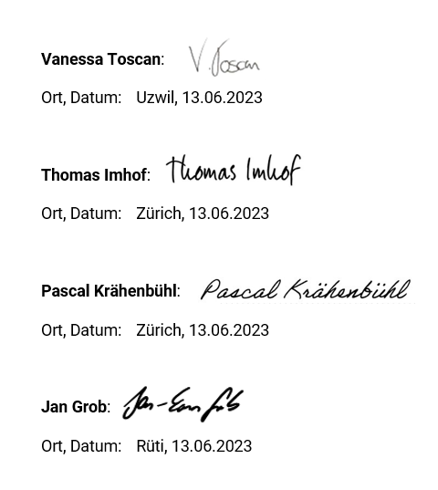